# Predictive Purchase Computation in Python

### Julien Hernandez Lallement

#### Orsay, April 2020

### Background

### Getting Data from the BI

### Heuristic approaches

### BetaGeo Model

### References

## **Background:**

If you work with transactional data, you probably have faced the challenge of computing meaningful KPIs that allow you to quantify how promising a given customer is / will be (based on past data). One computation that comes in handy when evaluating customers is the *predicted purchase probability*, i.e., a meaningful value that allows you to assess whether it might be worth investing in this customer, from a marketing perspective.

One might frame this questions as follows: given the purchase history of different customers, at the present moment, what will be the purchase pattern of these customers in a given future time window?  
The drawing below attempts to illustrate the question's framework:

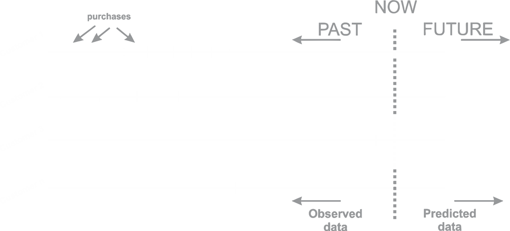

This notebook aims at documenting the logic, general approach and proceedings of such implementation at Orsay.

## **Getting Data from the BI**

Fist thing is to fetch the data from the BI.

Build a query with:  
1) Customer identifier (club card number, SalesForce ID, or whatever customer identifier you deem valid for your computation).  
2) Receipt ID  
3) Date of transaction

In order to train the model, you need to boil down a dataframe at the customer level with three parameters:  
1) frequency: number of purchase for that customer.  
2) recency: time between first and last purchas, in days, weeks or any meaningful scale for your business.  
3) T: age of the customer (birth = first purchase)

This would be a so-called RFM table (Recency-Frequency-Monetary; note that I will be discussing the monetary component in a separate post). So to be more accurate, a RF table ;)

Below, an example of what that data might look like:

| id | frequency | recency | T |
| --- | --- | --- | --- |
| 0 | 0.0 | 0.0 | 298.0 |
| 1 | 0.0 | 0.0 | 224.0 |
| 2 | 6.0 | 142.0 | 292.0 |

3 rows × 3 columns

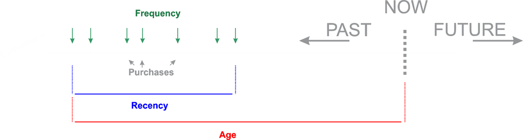

In the sections below, I will be using a public dataset, accessible to everyone, for reproducibility issues.

Just replace that data by Orsay data and you will obtain the score for orsay customers :)

## **Heuristic Approach: RFM score**

### (and why we can do better)

The dataset above is an example dataset of how transactional data might look like.

Now a very simple and easy approach to implement would be to calculate a so-called RFM score at the customer level. Data points from each data feature are categorized according to the distribution's quartile of that feature, which provides a score for each customer (in our case only RF score, since we do not have access to monetary value data).

| id | frequency | recency | T | r_quartile | f_quartile | RFScore |
| --- | --- | --- | --- | --- | --- | --- |
| 0 | 0.0 | 0.0 | 298.0 | 1 | 4 | 14 |
| 1 | 0.0 | 0.0 | 224.0 | 1 | 4 | 14 |
| 2 | 6.0 | 142.0 | 292.0 | 4 | 1 | 41 |
| 3 | 0.0 | 0.0 | 147.0 | 1 | 4 | 14 |
| 4 | 2.0 | 9.0 | 183.0 | 3 | 2 | 32 |

5 rows × 6 columns

We have produced, for each customer, a RF score that would already inform the business on which customers it might be worth focusing on.

However, while there is some virtue to this method (for instance interpretability, simplicity and speed of implementation), one might wonder whether it is wise to assume that past behavior maps onto future behavior that straightforwardly.

As we will see below, using this simple heuristic is not the most accurate way to proceed.Instead, we could use machine learning to predict purchase based on past purchase patterns for each customer.

## BetaGeo Model

### Model specification

**Pareto/NBD *vs* BetaGeo/NBD**

From an historical perspective, the Pareto/NBD model has been an attractive model to compute predicted purchase in different business models. However, the complexity of the Pareto/NBD model made it quite complex for businesses to implement for regular update of predictive purchase indexes. As an alternative, Fader & colleagues proposed the BetaGeo/NBD model, which produces an arguably comparable fit to the Pareto, but is simpler in implementation.

This documentation focuses on the BG/NBD model and test its implementation.  
For your information, there is some limitations to this model, in particular regarding the assumptions listed below. That goes beyong the goal of a documentation, but separate posts will discuss these matters for more expert users. Note that famously, all models are wrong, some are useful, @Orsay we should consider testing another model. In particular, the Pareto/NBD from a hierarchical Bayesian modeling perspective might really be a nice improvement in the future.

**Assumptions of the BG/NBD model**

(i) While active, the number of transactions made by a customer follows a Poisson process with transaction rate lambda.  
This is equivalent to assuming that the time between transactions is distributed exponential with transaction rate $\lambda$

\begin{equation*} \left(\ f(t_j | t_j-1 ; \lambda \right) = \left( \ \lambda e{}^{-\lambda(t_j - t_j-1) } \right) \left( t_j ; t_j-1 > 0\right) \end{equation*}

(ii) Heterogeneity in lambda follows a gamma distribution

\begin{equation*} \left( \ f(\lambda | r, \alpha \right) = \left( \ \frac{\alpha^r \lambda^{r-1} e^{-\lambda \alpha}}{\Gamma r} \right) \left(\lambda > 0\right) \end{equation*}

(iii) After any transaction, a customer becomes inactive with probability p. Therefore the point at which the customer “drops out” is distributed across transactions according to a (shifted) geometric distribution

\begin{equation*} \left( \ p(1-p)^{j-1}\right) \left(\ j = 1, 2, 3 ...\right) \end{equation*}

(iv) Heterogeneity in p follows a beta distribution

\begin{equation*} \left(\ f(p | a,b \right) = \left( \ \frac{p^{a-1} (1-p)^{b-1}}{B(a,b)} \right) \left( 0 \leq p \leq 1\right) \end{equation*}

(v) The transaction rate lambda and the dropout probability p vary independently across customers

Let's check whether the model has an acceptable performance to predict data. To do so, we will train the model on a training set and ask the model to predict data from a test set (AKA validation / holdout period).

### Model validation

| id | frequency_cal | recency_cal | T_cal | frequency_holdout | duration_holdout |
| --- | --- | --- | --- | --- | --- |
| 0 | 0.0 | 0.0 | 177.0 | 0.0 | 120 |
| 1 | 0.0 | 0.0 | 103.0 | 0.0 | 120 |

2 rows × 5 columns

The output above shows a split of the data into two sets for machine learning training.

```
<lifetimes.BetaGeoFitter: fitted with 5000 subjects, a: 1.96, alpha: 2.26, b: 3.48, r: 0.19>
```

We run some standard diagnostics, where we plot the average number of transactions in the test set vs training set, for observed ("frequency_holdout") and predicted data ("model predictions")

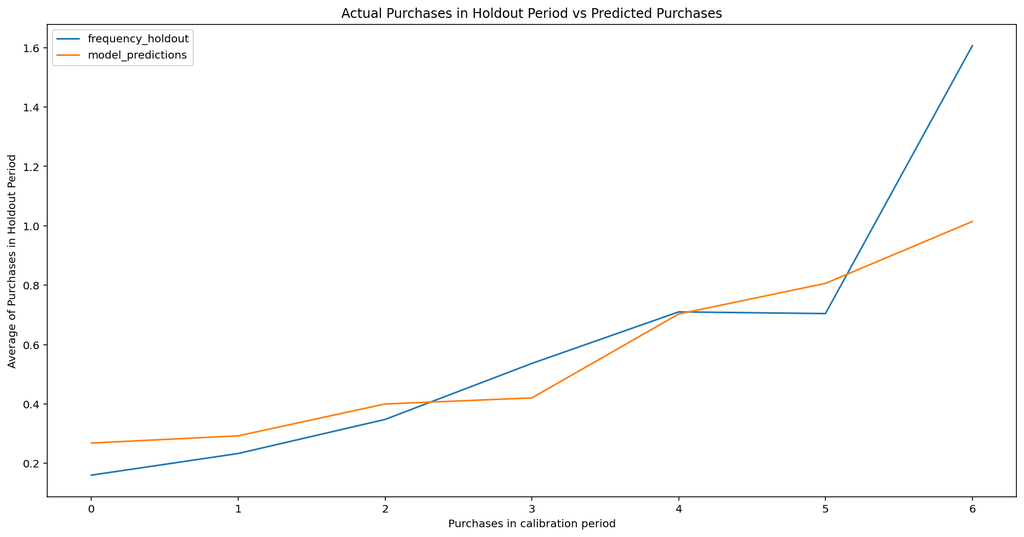

We can see that the model is quite good in picking up the purchase dynamics.  
Most customers make low number of purchases, which is probably why we get a better fit at lower bins, compared to higher bins.  
We could plot a model-free estimation of future purchases (or rather, model-based, the model being simple heuristics to estimate that value based on historical values).

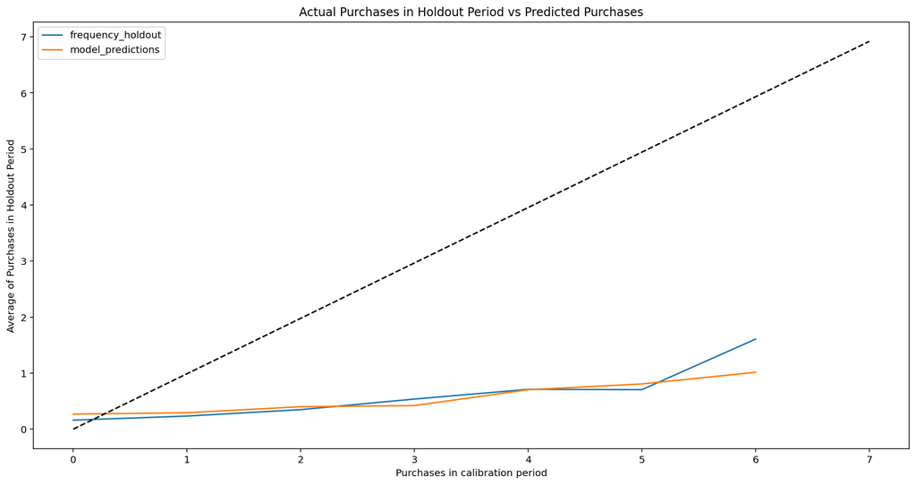

The plot above shows that estimation as the dotted black line. In this case, we would be overestimating purchases, which would impact our business in the future.

Now that we have validated the model using a validation set, let's train the model on the whole dataset.

### Model prediction

```
<lifetimes.BetaGeoFitter: fitted with 5000 subjects, a: 1.85, alpha: 1.86, b: 3.18, r: 0.16>
```

|  | coef | se(coef) | lower 95% bound | upper 95% bound |
| --- | --- | --- | --- | --- |
| r | 0.16 | 3.99e-03 | 0.16 | 0.17 |
| alpha | 1.86 | 9.54e-02 | 1.68 | 2.05 |
| a | 1.85 | 1.30e-01 | 1.60 | 2.10 |
| b | 3.18 | 2.94e-01 | 2.61 | 3.76 |

4 rows × 4 columns

There is a possiblity to produce useful matrix plots, that allow you to visualize the probability of customers being alive given the parameters, and some other features of your dataset. I won't use them here but I recommend you explore these plots, they might have an added value when explaining the process to stakeholders.

| id | frequency | recency | T | pred_purch_coming_week=12 |
| --- | --- | --- | --- | --- |
| 3552 | 63.0 | 180.0 | 181.0 | 3.77 |
| 1623 | 84.0 | 220.0 | 225.0 | 3.73 |
| 3348 | 73.0 | 246.0 | 249.0 | 3.17 |
| 1124 | 34.0 | 157.0 | 159.0 | 2.23 |
| 987 | 54.0 | 233.0 | 240.0 | 2.22 |
| 1540 | 30.0 | 116.0 | 122.0 | 2.15 |
| 456 | 35.0 | 247.0 | 251.0 | 1.48 |
| 3038 | 25.0 | 178.0 | 184.0 | 1.34 |
| 2275 | 21.0 | 156.0 | 160.0 | 1.31 |
| 443 | 27.0 | 222.0 | 223.0 | 1.30 |
| 4950 | 28.0 | 244.0 | 244.0 | 1.25 |
| 2065 | 38.0 | 269.0 | 283.0 | 1.18 |
| 4300 | 20.0 | 177.0 | 179.0 | 1.15 |
| 4569 | 51.0 | 266.0 | 283.0 | 1.15 |
| 1850 | 22.0 | 163.0 | 173.0 | 1.13 |
| 2325 | 25.0 | 254.0 | 256.0 | 1.04 |
| 4930 | 18.0 | 174.0 | 177.0 | 1.03 |
| 4773 | 23.0 | 211.0 | 220.0 | 1.01 |
| 1344 | 25.0 | 118.0 | 133.0 | 0.90 |
| 1847 | 23.0 | 287.0 | 291.0 | 0.83 |

20 rows × 4 columns

## **References**

Original research paper from Fader et al. 2005: http://brucehardie.com/papers/018/fader_et_al_mksc_05.pdf  
Lifetimes library documentation: https://lifetimes.readthedocs.io/en/latest/